# Mikroøkonomi (SFB10816)

Forelesningsnotater (shift+o for oversiksbilde)

Jørn I. Halvorsen og Joachim Thøgersen

2021/08/12 (updated: 2022-09-05)

# Timeplan med anbefalte oppgaver

Forelesning

Dag

Datoer

Modul

Uke

Literatur

Oppgaver

Temaer

Undervisningsform

Start

Timer

1

Fre

2022-08-26

1. Introduksjon

34

Hele kapittel 1. Kapittel 3.1-3.7, 3.9

1.4-1.8, 1.10,1.11, 3 (alle oppgavene)

Introduksjon til mikroøkonomi. Overbikk over fulllkomen konkurranse

Zoom

09:15

3/4

2

Tor

2022-09-08

2. Produsentteori:

36

Kapittel 4.1-4.7, 4.9

4.2, 4.4-4.8

Produksjon

Auditorium ?

12:15

3/4

2

Tor

2022-09-08

36

Kapittel 5.1-5.5, appendiks 5.1, 5.2

5 (alle oppgavene)

Inntekts- og kostnadsteori

Auditorium ?

12:15

3/4

3

Fre

2022-09-09

36

Kapittel 6.1-6.3, 6.5-6.6

6 (alle oppgavene)

Produsentens økonomiske adferd i gode- og arbeidsmarkedet

Auditorium ?

09:15

3/4

4

Tor

2022-09-29

3. Konsumentteori:

39

Kapittel 7 (hele, inkulsiv appendiks)

7 (alle oppgavene)

Konsumentens valg

Auditorium ?

12:15

3/4

5

Fre

2022-09-30

39

Kapittel 8.1-8.3, 8.7. Appendiks 8.1, 8.2

8 (alle oppgavene)

Konsumentens økonomiske adferd i gode- og arbeidsmarkedet

Auditorium ?

09:15

3/4

Forelesning

Dag

Datoer

Modul

Uke

Literatur

Oppgaver

Temaer

Undervisningsform

Start

Timer

7

6

Tor

2022-10-20

4. Markedsteori:

42

Kapittel 3 og 9

3 (alle oppgavene), 9.1-9.4

Fullkommen konkurranse

Auditorium ?

12:15

3/4

8

7

Fre

2022-10-21

42

Kapittel 10 (hele)

10.1-10.4

Ufulkommen konkurranse: monopol

Auditorium ?

09:15

3/4

9

8

Tor

2022-11-10

5. Markedsteori og andre emner:

45

Kapittel 11.3-11.4

11.3-11.4

Ufulkommen konkurranse: kartel, duopol, oligopol og monopolistisk konkurranse

Auditorium ?

12:15

3/4

10

8

Tor

2022-11-10

45

Kap. 12.1-12.3

12 (alle oppgavene)

Ufulkommen konkurranse: prisdiskriminering

Auditorium ?

12:15

3/4

11

9

Fre

2022-11-11

45

Kap. 13.2 (frem til s. 385 ‘kollektive goder’)

13.2,13.4-13.5

Effektivitet, velferd og markedsvikt

Auditorium ?

09:15

3/4

# Pensumliste

# Kursgodkjennelse

Består av to obligatorisk arbeidskrav (som må være bestått) for å kunne gå opp til skriftlig eksamen.

## Eksamen

Individuell, skriftlig firetimers eksamen.

Karakterregel: A-F.

Hjelpemidler: Godkjent kalkulator.

class: inverse, center, middle

# Kapittel 1: Introduksjon til mikroøkonomi. Overbikk over fulllkomen konkurranse

Oppdatert: 2022-09-05

## Hva handler økonomi om?

- Hva handler økonomi om?
- Mikroøkonomi er en del av samfunnsøkonomi. Hvilke temaer forbinder du med samfunnsøkonomi?
- En kort historie om en tur i butikken.
- Hvilke varer skal du kjøpe?
- Hvor mye skal du kjøpe av de ulike varene?
- Hva har økonomi med dette å gjøre? Tre relevante forhold:
- 1. Varene må ha blitt produsert.
- 2. Du må tilby noe for å bytte til deg varer. Betalingsmiddel
- og handel.
- 3. Du må ha skaffet betalingsmiddelet.

**Altså …**

- Selv i den «enkle» historien er det:
- Flere beslutninger involvert.
- Flere markeder involvert.
- Men: hvorfor får vi ikke alle varer vi vil ha? Rundt oss ser vi (og opplever selv) stor etterspørsel.Vi trenger jo en rekke ting, også i Norge.
  - Svaret er: KNAPPHET!

## Definisjon

- Definisjon av økonomi:

*Handler om bruken av knappe ressurser for å dekke menneskelig behov.*

- Den delen av samfunnsvitenskapene som studerer de valgene som individer, bedrifter, myndigheter og samfunn må ta, som følge av knapphet.
- To stikkord: behov og ressurser. Komme tilbake til…
- Bedriftsøkonomi og samfunnsøkonomi: Hvorfor skal dere lære samfunnsøkonomi på dette studiet? Relevant for bedrifter?

## Behov

- Økonomers behandling av behov og behovsdannelse. For enkelt? Psykologers behandling av samme tema…
- Et grovt skille:
- Som må dekkes
- Ønsker
- Behov avdekkes gjennom preferanser, som igjen kan avdekkes via etterspørsel.
- Kan behov skapes? Jepp. Men er slike skapte behov mer eller mindre viktig enn ”andre” behov, gitt knappe ressurser.
- En måte å skjære gjennom denne problemstillingen på er å legge til grunn *konsumentsuverenitet*.
- ”Folk vet best selv hva som er best for dem”.

## Ressurser

- Innsatsfaktor eller produksjonsfaktor kan betegnes som synonyme ord.  
  $\Rightarrow$ Faktorer som er ”input” i produksjonsprosessen.
- Kategorier:
- Naturressurser: Fornybare og ikke-fornybare
- Arbeidskraft
- Realkapital: Kan brukes direkte eller indirekte
- Ressurser som er KNAPPE.
- Er penger ressurser??

## Så kjernen i økonomifaget er dermed:

- Ettersom det er knapphet på ressurser kombinert med store behov, er det ønskelig å bruke ressursene smartest mulig.  
  $\Rightarrow$ Sikre at utnyttelsen av ressursene er optimal.
- Merk at ressurser ofte har alternativ anvendelse. Dette innebærer at dersom vi bruker en ressurs til å produsere en vare, kan ikke den samme ressursen brukes samtidig til å produsere en annen vare. Av og til ikke i det hele tatt.

## Alternativkostnad

- Dette er et helt sentralt begrep i økonomifaget.
- Bruk av ressurser tilfører en verdi som skal dekke menneskelige behov.
- Ressurser har en alternativ anvendelse. Den beste alternative anvendelse har også en verdi. Denne verdien tapes når vi bruker ressursen til et bestemt formål.
- Dette tapet er alternativkostnaden.
  - *Alternativkostnaden er altså verdien av beste alternative anvendelse.*

[figure not shown]

## To sentrale spørsmål: spørsmål 1

- (1): Hvordan vil ulike valg bestemme hvilke goder som produseres, hvordan de produseres og for hvem?
- Goder skal dekke behov og ønsker.
- Men hva skal vi produsere og hvordan vet vi det?
- Hvor mye skal produseres?
- Hvordan? Vil ny teknologi erstatte arbeidskraft og føre til økt arbeidsledighet?
- Hvem skal det produseres til? Inntektsulikhet.

## To sentrale spørsmål: spørsmål 2

- (2): Er det slik at valg som fremmer egeninteresse også fremmer samfunnets beste?
- Brukes de knappe ressursene på best mulig måte?
- Egeninteresse: valg som er best for en selv.
- Sosial interesse: valg som er best for samfunnet som helhet.
- Dine valg påvirker mange og valgene er knyttet sammen. Anta at alle valgene er gjort av egeninteresse, er det mulig at resultatet også er det beste for samfunnet som helhet?
- Adam Smith: JA. «Usynlige hånd».

## Økonomisk tankemåte: metodologiske tradisjoner

- Økonomifaget defineres ut i fra tema som studeres, men det er en del metodiske tradisjoner.
1. Et valg er en avveining (trade-off). Knapphet skaper valg.
2. Kostnad: det du må gi opp.
3. Fordel (benefit) eller nytte: Gleden du oppnår. Preferanser.
4. Rasjonelle valg. Bruker all tilgjengelig informasjon, og veier så sammen kostnader og fordeler.
5. Valg på marginen. Ikke enten-eller, men hvor mye. Marginalkostnad og marginalfordel.
6. Valg responderer på incentiver. Incentiv: Belønning eller straff som følge av valg.

## Økonomi som vitenskap

### Modeller

- Bruker økonomiske modeller.
- Hva er en modell? En forenklet beskrivelse av virkeligheten. Bygger pr. definisjon på forutsetninger.
- Hvorfor bruke modeller? For å kunne fokusere på ett eller noen aspekter av virkeligheten. Virkeligheten er komplisert…
- Modeller gjør at vi kan rense vekk momenter som vi tror ikke har noen spesiell innvirkning på vårt spørsmål.

## Økonomi som vitenskap

### Skillet mellom mikroøkonomi og makroøkonomi

- Det finnes flere måter å strukturere økonomifaget på. Disiplinen består av en rekke underområder.
- Mikroøkonomi: Søker å forklare aktørers beslutninger, tilpasning og interaksjon.
- Aktører: Bedrifter, konsumenter, markeder.
- Makroøkonomi: Søker å studere og forklare aggregerte størrelser. Økonomien under ett.
- Makroøkonomi kan deles inn i konjunkturteori og økonomisk vekst.

## Appendiks (alle figurene samlet)

[figure not shown]

class: inverse, center, middle

# Kapittel 3: En markedsmodell med fullkommen konkurranse

Oppdatert: 2022-09-05

## Innledning

- Bytteøkonomi og markedsøkonomi: I en markedsøkonomi (pengeøkonomi) byttes varer *indirekte*.
- Et marked består av en tilbudsside og en etterspørselsside.
- Vi skal nå se på den enkleste markedsformen i økonomisk teori.
- Markedsformen er likevel nyttig:
  - Selvstendig analyseapparat.
  - Kan utvides langs mange dimensjoner.
  - Er samfunnsøkonomisk effektiv (hva som menes med dette skal vi bruke en del tid på senere).
  - Er en referansemodell som andre modeller og resultater kan sammenlignes mot.

## Bakgrunn

- Store deler av kurset vil handle om teorien bak denne modellen. MERK at oppbyggingen gir oss flere selvstendige modeller som er nyttige for økonomiske analyser.
- Modellen går langt tilbake:
  - Adam Smith (1723-1790) $\rightarrow$
  - Nyklassikerne og John Stuart Mill (1806-1873) $\rightarrow$
  - Alfred Marshall (1842-1924) $\rightarrow$
  - Paul Samuelson (1915-2009) mfl.
- Vi skal komme tilbake til forutsetningene bak denne modellen i kapittel 9.
- Men merk spesielt: Aktørene er *pristakere* og har ingen innflytelse på pris som enkeltaktør, men *summen* av aktørenes adferd bestemmer markedsprisen.

## Markedsetterspørsel

- Etterspørsel etter varer og tjenester. Ofte kalles varer + tjenester for goder.
- Hva bestemmer etterspørselen? Priser, inntekt med mer.
- Etterspørselsloven:
  - Økt pris $\rightarrow$ lavere etterspørsel, alt annet konstant (cet.par.).
  - Flere forhold holdes her konstante. Vi ser kun på endringer i prisen på varen. En endring i denne vil flytte oss langs kurven.
  - En endring i konstantene vil føre til skift i kurven.
- Fra et individs etterspørsel til markedsetterspørsel.

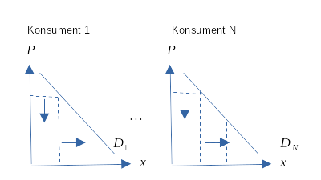

## Markedstilbud

- Tilbud av varer og tjenester. Tilbudet utgjøres av bedriftene eller produsentene. Tilbudet er altså produksjonen.
- Hva bestemmer tilbudet? Pris på ferdigvare og innsatsfaktorer. Matematisk på tavla.
- Tilbudsloven:
  - Økt pris $\rightarrow$ økt tilbud, cet.par. Kurve.
  - Endringer i prisen på varen fører til bevegelse langs kurven.
  - En endring i konstantene fører til skift i kurven.
- Fra en bedrifts tilbud til markedstilbud.

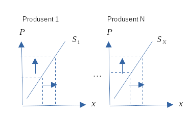

## Markedslikevekt

- Utgangspunkt: markedets E-kurve og T-kurve.
- Likevekt: dersom ingen aktører ønsker å endre den eksisterende økonomiske tilpasning.
  - $X^S = X^D$
  - Overskuddsetterspørsel: $X^D > X^S$
- Anta at prisen er lavere enn likevektspris (makspris).
  - Overskuddstilbud: $X^S > X^D$
- Anta at prisen er over likevektsprisen (minpris).
- Ingenting i modellen som tilsier stabilitet. Men utenfor modellen kan vi resonnere omkring markedskrefter, slik de er beskrevet av Adam Smith.

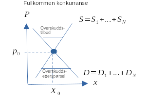

## Komparativ statikk/ skift i kurvene

- Vi vet at tilbuds- og etterspørselskurvene er konstruert under en antagelse om at flere forhold antas konstante. Dersom det skjer endringer i noen av disse forholdene, vil kurvene forskyves i diagrammet. La oss se på noen av disse forholdene.

**Tilbudskurven** - Ble tegnet for: - gitt teknologi for bedriften, - gitte priser på innsatsfaktorene.

**Etterspørselskurven**

- Ble tegnet for:
  - en gitt behovsstruktur for konsumenten,
  - gitt samlet inntekt for konsumenten,
  - gitt inntektsfordeling,
  - gitte priser på andre goder.

### Helningens betydning

- Helningen på tilbuds- og etterspørselskurven påvirker hvordan endringer i markedet påvirker pris og mengde. La oss se på et eksempel der lavere pris på innsatsfaktorene har ført til et positivt skift i tilbudskurven.

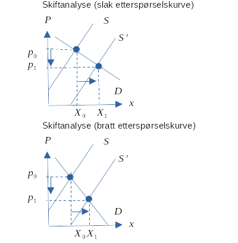

## Effekten av en avgift

- En avgift kan ha flere hensikter, men spesielt er to ting viktig:
  1. Inntekt for staten
  2. Endrer markedsresultatet. Aktuelt ved behov for korrigering av nåværende situasjon (tilpasning).
- Avgiften kan pålegges kjøperne og selgerne.

Anta nå at avgiften $\tau$ blir pålagt selgerne - Dersom avgiften pålegges produsentene, vil kostnadene til bedriften stige. Dette skifter isolert sett tilbudskurven innover. Den vertikale størrelsen på skiftet er lik avgiften $\tau$. Resultater: - Staten får inn $\tau$ kr. pr. enhet. - Konsumenten betaler: $P^K$ - Produsenten mottar: $P^P$ Produsenten ”sender” nå avgiften til staten, men begge bærer byrden!!

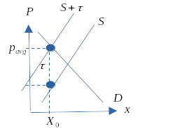

## Maksimal- og minsteprisen

- Maksimalpris har vi dersom markedsprisen blir overtyrt ved at myndighetene setter et makspris som er *lavere* enn markedsprisen.

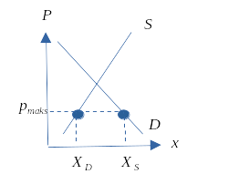

- Minstrepris har vi dersom markedsprisen blir overtyrt ved at myndighetene setter et minstepris som er *høyere* enn markedsprisen.

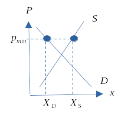

## Produksjonsmulighetskurven (PMK)

- Produksjonsmulighetskurven (PMK)
- PMK: kurven kan brukes til å illustrere hvordan produksjonsmulighetene er begrenset. Dette fører til et ressursallokeringsproblem. Videre skal vi illustrere forskjellen på kort og lang sikt.
- Kurven bygger på en antagelse om at alternativkostnadene øker ved stadige overføringer av ressurser mellom sektorer.
- Forutsetninger: to produkter, gitt mengde produksjonsfaktorer (kort sikt) og produksjonsteknologien er konstant.

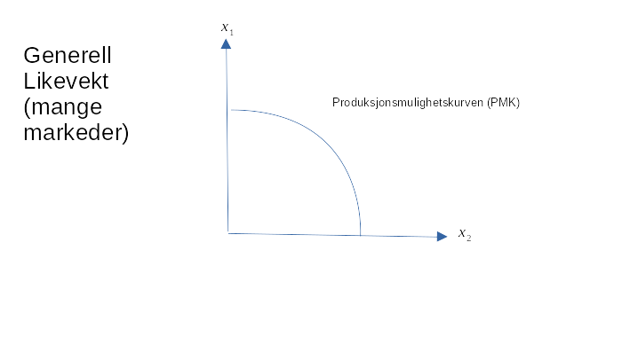

## Appendiks (alle figurene samlet)

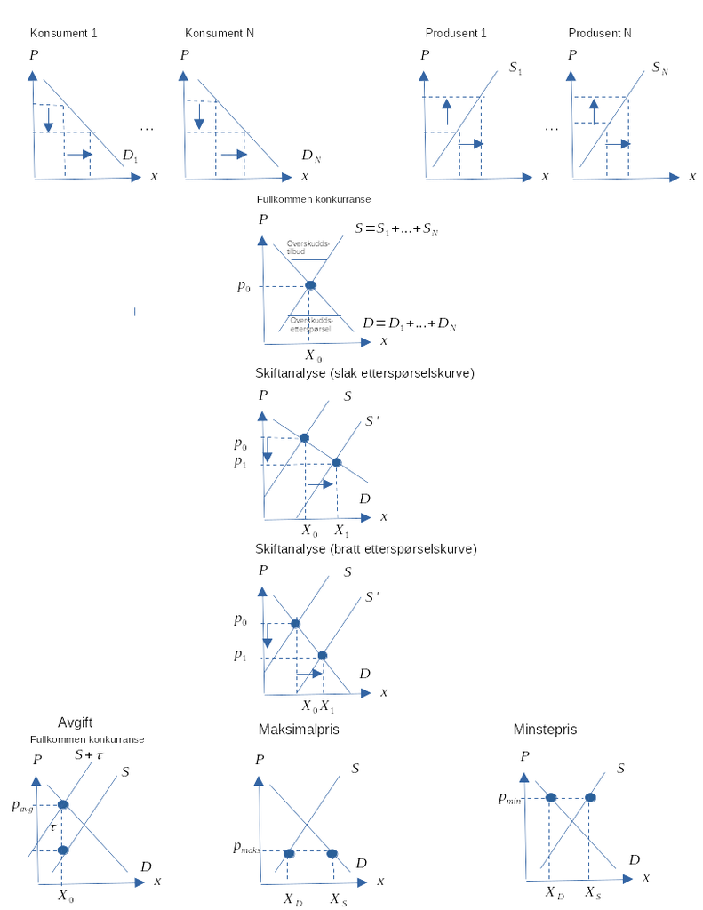

```r
knitr::knit_exit()
```

## Innledning

- Produsentene eller bedriftene er en av hovedaktørene i en økonomi.
- Produsentens rolle: tilby de varer og tjenester som etterspørres i et samfunn. Basert på konsumentens ønsker må produsenten vite hva som skal produseres, mengde og lokalisering.
- Teknologisk perspektiv: Produsenten bruker innsatsfaktorer til å omforme råvarer til ferdige produkter.
- Vi forenkler produksjonsbildet ved å anta at produsenten bruker to innsatsfaktorer, $N$ og $K$, til å produsere ett produkt, $x$. $N$ er arbeidskraft og $K$ er realkapital.

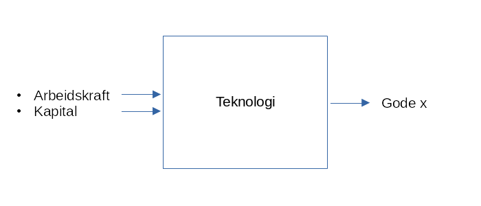

- Bedriften må altså velge effektiv produksjonsprosess.
- Økonomisk perspektiv: Her består valget i å velge hvor mye bedriften skal produsere og tilby av produktet.
- For å kunne få størst mulig overskudd må vi kjenne til inntekter og kostnader. Kostnadene er igjen svært avhengig av det teknologiske valget.
- Vi må derfor sammenkoble elementer fra begge disse perspektivene.

## Produksjon og teknologiske forhold

- Vi tar utgangspunkt i produksjonsbildet med to innsatsfaktorer og ett produkt.
- Produktfunksjon:
- $x = f(N, K)$
- Viser for enhver mulig faktorkombinasjon det maksimale antall enheter som kan produseres av produktet.
- $f$ beskriver formen på avhengighetsforholdet mellom produksjonsmengden og innsatsfaktorene. Kan tolkes som forhold (faktorer) som endrer produksjonsmengden uten å endre mengden av innsatsfaktorene $N$ og $K$.

**Talleksempel på en produktfunksjonen**

[output not shown]

## Forutsetninger om produktfunksjonen

- For analytiske formål antas funksjonen kontinuerlig og to ganger deriverbar:

.pull-left[ Arbeidskraft]

.pull-right[ Kapital]

- Positive, men avtagende grenseproduktiviteter.
- De førsteordens partielle deriverte uttrykker grenseproduktiviteten: hvor mye produsert kvantum endres ved en liten endring i bruken av vedkommende innsatsfaktor.

## Loven om avtakende utbytte gjelder altså her.

## Isokvanter og MTSB for produksjon

- For å representere produktfunksjonen grafisk skal vi bruke et redskap fra matteboka. Nemlig nivåkurver.
- Nivåkurven kalles her en isokvant: viser alle kombinasjoner av N og K som gir samme produserte kvantum.
- Grafisk illustrasjon på tavla.

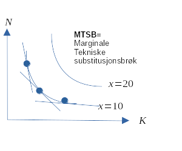

- Isokvantens form bygger på følgende prinsipp: jo mer bedriften har av en innsatsfaktor, jo mer kan den bytte for en ekstra enhet av den andre faktoren, gitt at produksjonsmengden skal være den samme.
- Formell utledning av MTSB. Ta utgangspunkt i produktfunksjonen og total differensier.

$$\overline{x} = f(K,N)$$

Dersom vi totaldifferensierer dette uttrykket får vi

$$\begin{equation*}
\Delta \overline{x} = f'_{K}(K,N)\Delta K + f'_{N}(K,N)\Delta N
= 0
\end{equation*}$$

Uttrykket ovenfor kan skrives som

$$\begin{equation*}
f'_{K}(K,N)\Delta K =- f'_{N}(K,N)\Delta N \\
\frac{\Delta K}{\Delta N} = - \frac{f'_{N}(K,N)}{f'_{K}(K,N)}
\end{equation*}$$

$$\begin{equation*}
MTSB \equiv -\frac{\Delta K}{\Delta N}
= \frac{f'_{N}(K,N)}{f'_{K}(K,N)}>0
\end{equation*}$$

- MTSB beskriver helningen på en isokvant for en gitt faktorkombinasjon, dvs. i ett punkt på isokvanten.
- Merk at MTSB er gitt ved forholdet mellom grenseproduktivitetene.

**Eksempel 4.2 fra pensumbok**

3. Anta at produktfunksjonen er gitt ved: $x = N^{0,7}+K^{0,3}$ Regn ut MTSB for denne produktfunksjonen.

Grenseproduktiviteten til arbeidskraften er gitt ved
$$\frac{\partial x}{\partial N} = 0,7N^{0,7-1} = 0,7N^{-0,3}$$

Grenseproduktiviteten til kapitalen er gitt ved
$$\frac{\partial x}{\partial K} = 0,3K^{0,3-1} = 0,3K^{-0,7}$$

MTSB blir derfor
$$MTSB \equiv \frac{\Delta K}{\Delta N} = \frac{\frac{\partial x}{\partial
N}}{\frac{\partial x}{\partial K}} = \frac{0,7N^{-0,3}}{0,3K^{-0,7}}$$

## Substitusjonsegenskaper

- Dette sier noe om hvor lett det er å erstatte innsatsfaktorer med hverandre.
- For eksempel: I noen bransjer er det lettere å erstatte arbeidskraft med kapital enn i andre.
- Dette kan fremstilles med formen på isokvanten.
- Ytterkantene: perfekt substitusjon og ingen substitusjon (perfekte komplementer).

.pull-left[ Linear produksjonsteknolog (perfekte substitutter)]

.pull-right[ Lientof produksjonsteknologi (fast produksjonsforhold)]

## Skalaegenskaper

- Mens grenseprodukt viser endring i bruken av en innsatsfaktor, viser skalaendringer endringer i bruken av alle innsatsfaktorer.
- Definisjon: Skalaegenskapene sier noe om hvor mye produksjonsmengden endres ved proporsjonale endringer i bruken av innsatsfaktorene.
- Proporsjonale endringer innebærer at forholdet mellom N og K er konstant. Faktorstråle…
- Anta en proporsjonal økning på 10%.
- Hva skjer med produksjonsmengden (MERK: produksjonsprosesser kan variere i skala)?
- 1. Konstant skalautbytte
- Skalaøkning på y % $\Rightarrow$ økning i produsert kvantum på y %.

[figure not shown]

- 2. Avtagende skalautbytte
- Skalaøkning på y % $\Rightarrow$ økning i produsert kvantum på mindre enn y %.

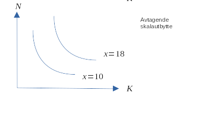

- 3. Økende skalautbytte
- Skalaøkning på y % $\Rightarrow$ økning i produsert kvantum på mer enn y %.

[figure not shown]

## Appendiks (alle figurene samlet)

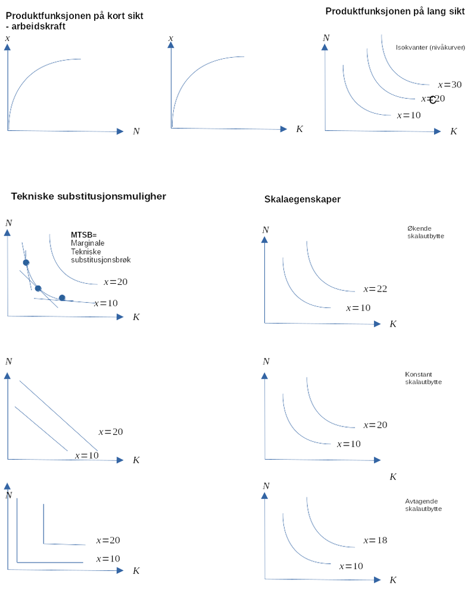

class: inverse, center, middle

# Kapittel 5: Produsentteori: Inntekts- og kostnadsteori

Oppdatert: 2022-09-05

# Innledning

- Vi skal starte med å se litt generelt på inntekter, kostnader og ulike kostnadsbegreper.
- Deretter skal vi se på kostnadslinja som ser kostnadene i forbindelse med faktorbruk.
- Vi skiller mellom kort og lang sikt.
- Til slutt skal vi se på bedriftens optimale tilpasning, hvor vi vil legge til grunn at bedriften har et mål om å maksimere antall produserte enheter under en budsjettbetingelse.

# Inntekter på kort og lang sikt

- Bedriftens inntekter bestemmes av antall enheter den selger, og prisen på disse enhetene.
- Pris: $p$. Mengde: $x$.
- Inntekt: $R=px$. Stigende i et $(x,R)$-diagram
- Grenseinntekt: endring i inntekt ved en marginal endring i solgt kvantum: $R'(x)$
- Gjennomsnitsinntekt: inntekt per produsert enhet: $\overline{R}$.

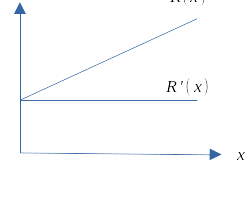

**Tabelleksempel for salgsinntekter**

| Solge enheter | Pris per enhet | Salgsinntekt | Grenseinntekt | Gjennomsnittsinntekt |
| --- | --- | --- | --- | --- |
| 1 | 1000 | 1000 |  | 1000 |
| 2 | 1000 | 2000 | 1000 | 1000 |
| 3 | 1000 | 3000 | 1000 | 1000 |

# Kostnader på kort sikt

- Kostnader: de beløp som påløper som følge av virksomhet.
- Faste kostnader $(C_F)$ : kostnader som er uavhengige av produsert kvantum.
- Variable kostnader $(C_V$): varierer i takt med produsert kvantum $\Rightarrow$ $CV = CV(x)$
- Totale kostnader $(C)$:
- $C = CF + CV$
- Gjennomsnittskostnader (enhetskostnader)
  - Disse finner vi ved å dividere de respektive kostnadene med antall produserte enheter. På tavla
  - $\overline{C}=\overline{C}_F+\overline{C}_V$
- Grensekostnader ( $GK$ eller $C'$ )
  - Endringen i bedriftens totale kostnade ved en liten endring i produsert kvantum

## $GK=\frac{dC(x)}{dx}=C'(x)$

.pull-left[ Kostnader uten faste kostnader]

.pull-right[ Kostnader med faste kostnader]

## Sammenhengen mellom gjennomsnittskostnad og grensekostnad

**Tabelleksempel a): med avtagende marginalproduktivitet (mest relevant for dette kurset) og uten faste kostnader**

| Produserte enheter | Lønnskostnader | Antall arbeidere | Variable kostnader |
| --- | --- | --- | --- |
| 1 | 1000 | 1 | 1000 |
| 2 | 1000 | 2 | 2000 |
| 3 | 1000 | 3.1 | 3100 |

| Faste kostnader | Totale kostnader | Grensekostnader | Gjennomsnittskostnad |
| --- | --- | --- | --- |
| 0 | 1000 |  |  |
| 0 | 2000 | 1000 | 1000 |
| 0 | 3100 | 1100 | 1032 |

**Tabelleksempel b): med økende marginalproduktivitet (mindre relevant) og uten faste kostnader**

| Produserte enheter | Lønnskostnader | Antall arbeidere | Variable kostnader |
| --- | --- | --- | --- |
| 1 | 1000 | 1 | 1000 |
| 2 | 1000 | 2 | 2000 |
| 3 | 1000 | 2.9 | 2900 |

| Faste kostnader | Totale kostnader | Grensekostnader | Gjennomsnittskostnad |
| --- | --- | --- | --- |
| 0 | 1000 |  |  |
| 0 | 2000 | 1000 | 1000 |
| 0 | 2900 | 900 | 966 |

**Tabelleksempel c): med avtagende marginalproduktivitet og med faste kostnader**

| Produserte enheter | Lønnskostnader | Antall arbeidere | Variable kostnader |
| --- | --- | --- | --- |
| 1 | 1000 | 1 | 1000 |
| 2 | 1000 | 2 | 2000 |
| 3 | 1000 | 3.1 | 3100 |

| Faste kostnader | Totale kostnader | Grensekostnader | Gjennomsnittskostnad |
| --- | --- | --- | --- |
| 2000 | 3000 |  | 3000 |
| 2000 | 4000 | 1000 | 2000 |
| 2000 | 5100 | 1100 | 1700 |

# Kostnadslinjen (lang sikt)

- Totale kostnader for bedriften er summen av variable og faste kostnader. La oss nå se bort fra de faste ettersom alle faktorer antas å være variable på lang sikt.
- Vi antar at bedriftens kostnader kan uttrykkes ved summen av utgiftene på de to innsatsfaktorene.
- Pris på N: w
- Pris på K: r
- $C = wN + rK$

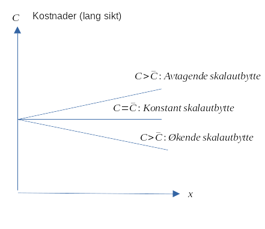

Totale kostnader (C) er da gitt ved:

$$C = wN + rK$$

Isokost

$$C^o= wN + rK$$

Helingen på isokostline

$$\begin{equation}
\Delta C^0= w\Delta N + r\Delta K = 0 \\
r\Delta K = -w\Delta N \\
\frac{\Delta K}{\Delta N} = - \frac{w}{r}
\end{equation}$$

Bruker hele budsjettet på arbeidskraft $\Rightarrow K=0$

$$\begin{equation}
C^0= wN + r0 = wN \\
C^0/w = N \\
N = C^0/w
\end{equation}$$

Bruke hele budsjettet (kostnaden) på kapital $\Rightarrow N=0$

$$\begin{equation}
C^0= w0 + rK = wN \\
C^0/r = K \\
K = C^0/r
\end{equation}$$

# Kostnadslinjen og Isokostlinja

## Optimal tilpasning

- Isokostlinja viser alle faktorkombinasjoner som gir samme totale kostnad.
- Endrede kostnader: parallellforskyver linja. MERK: en endring i kostnader kan tolkes som en endring i bedriftens kostnadsramme. Typisk for bedrifter i offentlig sektor, som opererer under tildelte bevilgninger.

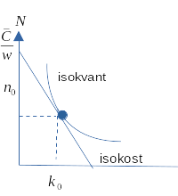

## Endrede faktorpriser: helningen på linja endres.

.pull-right[ Redusert pris på arbeidskraft]

# Produktmaksimering ved en gitt kostnadsramme

- Målsetting er her å maksimere produsert kvantum innenfor en gitt kostnadsramme.
- Dette kan være typisk for en bedrift i offentlig sektor, der de økonomiske rammebetingelsene utgjøres av en gitt kostnadsramme eller et gitt budsjett som er blitt tildelt over de offentlige budsjetter.
- Grafisk løsning
- Tar utgangspunkt i produktfunksjonen:
- $x = f(N, K)$
- Helningen er gitt ved MTSB.
- Tar så utgangspunkt i kostnadslinja:
- $C = wN + rK$
- Kombinerer disse for å finne optimal tilpasning.

Max $x=f(K,N)$ gitt $Ĉ^0=wN +rK$ gitt (beskrankning)

Lagrange metode:

$$\begin{equation}
L = f(K,N) - \lambda(wN+rK-C^0)
\end{equation}$$

Første ordens betingelsen er gitt ved

$$\begin{equation}
\partial L/\partial N = f'_{N} - \lambda w =0 \\
\partial L/\partial K = f'_{K} - \lambda r =0
\end{equation}$$

Kombinerer de to første ordens betingelsene gir oss løsningen

$$\begin{equation}
\lambda w/\lambda r=w/r = \frac{f'_{N}}{f'_{K}} = MTSB
\end{equation}$$

Optimal løsning er også her karakterisert ved tangeringspunktet mellom isokvant og isokostlinjen.

# Substitumalen: økonomisk substitusjon

- Dersom vi tenker oss flere endringer i bedriftens kostnadsramme med tilhørende optimale isokvant, vil vi få frem en rekke tangeringspunkter. Kostnadsminimering og produktmaksimering gir samme resultat.

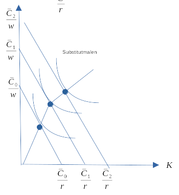

## Kurven gjennom disse kalles ekspansjonsveien eller substitumalen.

- På ethvert punkt på denne kurven kan det leses av produksjonsmengde, tilhørende kostnader og etterspørsel etter innsatsfaktorer.
- Forts. Substitumalen: økonomisk substitusjon
- Alle punktene på substitumalen viser tilpasninger der det ikke er mulig å øke produktmengden, uten at kostnadene øker. Det er heller ikke mulig å redusere kostnadene, uten samtidig å redusere produsert kvantum.
- Dersom bedriften er utenfor substitumalen kan den alltid bedre sin situasjon ved økonomisk substitusjon.

## Appendiks (alle figurene samlet)

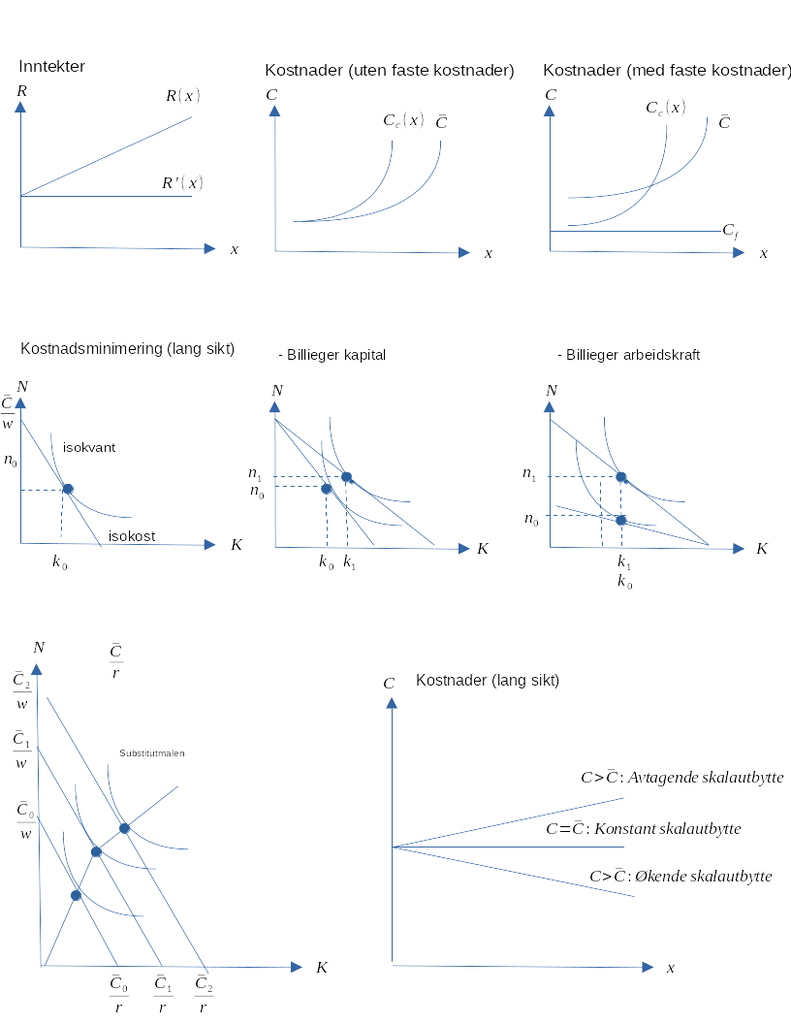

class: inverse, center, middle

# Kapittel 6: Produsentteori: Produsentens økonomiske adferd i gode- og arbeidsmarkedet

Oppdatert: 2022-09-05

## Fortjenestemaksimering som mål for bedriften

- Vi skal nå legge til grunn at bedriften har som mål å maksimere fortjenesten eller profitten.
- Vi skal også legge til grunn av bedriften betrakter alle priser som gitte (gode- og faktorpriser).
- Bedriften tilpasser seg på to markeder:

  - ```
    godemarkedet
    ```

  - faktormarkedet (arbeidskraft og kapital)
- På faktormarkedet kjøper bedriften innsatsfaktorer og må velge de kvantum av faktorene som maksimerer fortjenesten.
- På godemarkedet må bedriften velge den produksjonsmengden som maksimerer fortjenesten. Altså: to valg!!

## Hvor stor skal produksjonen være (kort sikt)?

- For å finne svar på dette lar vi produksjonsmengden være variabel.
- Hensikten med denne tilnærmingen er å analysere hvordan bedriften varierer produsert kvantum/ antall enheter den produserer, for å oppnå høyest mulig fortjeneste.
- Produsentens valgvariabel er dermed kvantumet $x$.

## En fordel med denne tilnærmingen er at den gir sammenhengen mellom pris og produsert kvantum på en enkel måte. Dette kan så brukes til å utlede bedriftens tilbudskurve, og i neste omgang markedets tilbudskurve.

### Fortjenestemaksimering med variabel produksjonsmengde (kort sikt)

- Produksjon: $x = f(N)$
- Kostnader: $C(x) = CV(x) + CF$
- Salgsinntekt: $R = px$
- Maks profitt: $F = R – C$ som gir $F=px – CV(x) – CF$
- Bedriften ønsker å maksimere dette uttrykket mhp. bruken av arbeidskraften. Formelt kan vi uttrykke dette som:
  $$\underset{x}{\text{Maks }} F=px-C(x)$$
  —

**Løsning og tolkning**

1.ordensbetingelsen er gitt ved
$$p = C'(x)$$
Produksjonen tilpasser seg der hvor produktprisen er lik grensekostnaden.

2.ordensbetingelsen (som sikrer maksimum)
$$F''(x)=p-C''(x) < 0 \Rightarrow C''(x) > 0$$

Kostnadsfunksjonen må være konveks (som vi tidligere har sett at kan komme som et resultat av avtagende grenseproduktivitet mhp. bruken av arbeidskraft)

.pull-left[

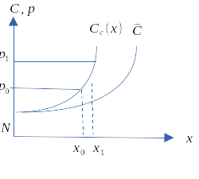

]

.pull-right[

[figure not shown]

]

## Hvor stor skal produksjonen være (lang sikt)?

- Dersom vi antar avtagende skalautbytte, vil denne løsningen også gjelde på lang sikt.
- For konstant eller økende skalautbytte, vil ikke maksimeringen av fortjenesten gjør det mulig å bestemme det optimale nivået på $x$ (2. ordensbetingelsen er ikke oppfylt).
- Senere i kurset, skal vi se at for dette tilfelle vil det være etterspørselskurven som bestemmer hvor mye som bli produsert i markedet.

## Bedriftens tilbud på kort og lang sikt

.pull-left[

]

.pull-right[

]

## Hvor stor skal faktorbruken være (kort sikt)?

- For å finne svar på dette spørsmålet betrakter vi innsatsfaktoren arbeidskraft som variable, og at disse er beslutningsvariablen til bedriften.
- Bedriften ønsker størst mulig overskudd.
- Produksjon: $x = f(N)$
- Kostnader: $C = wN$
- Salgsinntekt: $R = px$
- Profitten er gitt som inntekter (R) minus kostnader (C): $F = R – C$
- Bedriften ønsker å maksimere dette uttrykket mhp. bruken av arbeidskraften. Formelt kan vi uttrykke dette som:
  $$\underset{N}{\text{Maks }} F=pf(N, K)-wN$$

**Løsning og tolkning**

1.ordensbetingelsen er gitt ved
$$pf'(N)=W$$
Bruken av arbeidskraften bestemmes der hvor verdien av grenseproduktiviteten er lik det nominelle lønnsnivået.

2.ordensbetingelsen (som sikrer optimum)
$$pf''(N) < 0$$

## Hvor stor skal faktorbruken være (lang sikt)?

- Dersom vi antar avtagende skalautbytte, vil løsningen på forrige side inneholde en ny førsteordensbetingelse som krever at $pf'(K,N)=r$ (dvs. optimalt nivå på kapital tilpasses der hvor verdien av grenseproduktiveteten er lik kapitalkostnaden)
- For konstant eller økende skalautbytte, har vi antydet at nivået på $x$ vil bære bestemt fra etterspørselssdien. For å finne optimal faktorbruk i dette tilfelle kan vi for en gitt produksjons minimere faktorutlegget.
- Formelt kan vi skrive dette som

$$\begin{equation*}
\text{ Min } C=wN +rK \text{ gitt } x^0=f(K,N)
\end{equation*}$$

Vi kan løse dette ved bruk av Lagrange metode. Lagrangefunksjonen er her gitt ved:

$$\begin{equation}
L = f(K,N) - \lambda(wN+rK-C^0)
\end{equation}$$

De to første ordens betingelsen er gitt ved

$$\begin{equation*}
\partial L/\partial N = f'_{N,K} - \lambda w =0 \\
\partial K/\partial K = f'_{N,K} - \lambda w =0
\end{equation*}$$

Kombinerer de to første ordens betingelsene gir oss løsningen

$$\begin{equation*}
\lambda w/\lambda r=w/r = \frac{f'_{N}}{f'_{K}} = MTSB
\end{equation*}$$

Optimal løsning er også her karakterisert ved tangeringspunktet mellom isokvant og isokostlinjen.

## Appendiks (alle figurene samlet)

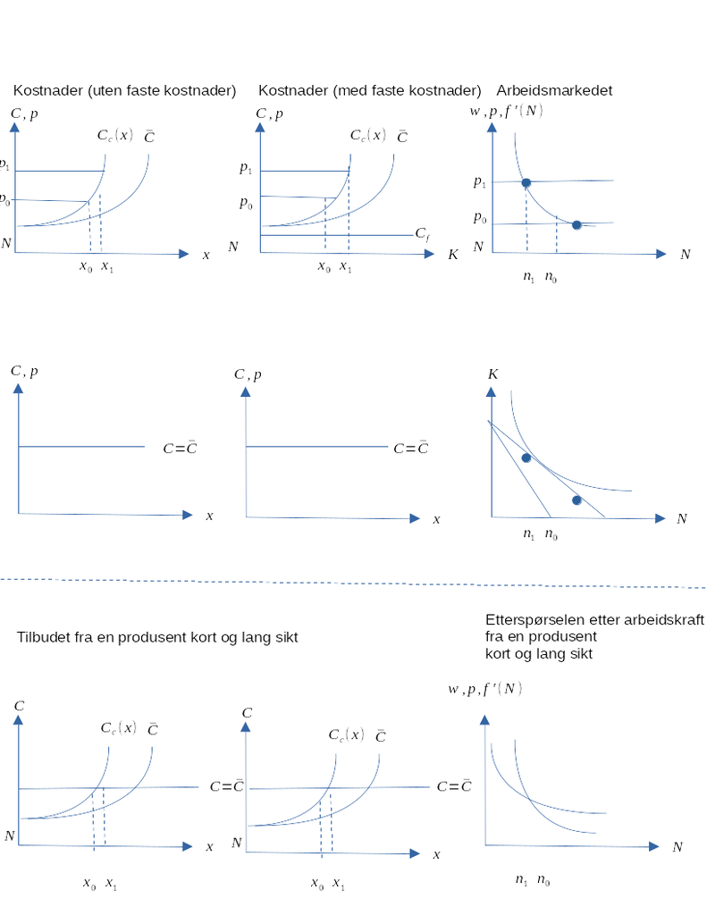